# 1.0 Prevendo o Nível de Satisfação dos Clientes do Santander

A satisfação do cliente é uma medida fundamental de sucesso. Clientes insatisfeitos cancelam seus serviços e raramente expressam sua insatisfação antes de sair. Clientes satisfeitos, por outro lado, se tornam defensores da marca!

O Banco Santander está pedindo ajuda para identificar clientes insatisfeitos no início do relacionamento. Isso permitiria que o Santander adotasse medidas proativas para melhorar a felicidade de um cliente antes que seja tarde demais.

Dataset disponível no Kaggle em: https://www.kaggle.com/c/santander-customer-satisfaction

#### Objetivo

Prever se um cliente está satisfeito ou insatisfeito com base na sua experiência bancária.

# 2.0 Módulos

```python
# módulos utilizados
import pandas as pd
import numpy as np

# visualização
import matplotlib.pyplot as plt
import seaborn as sns

# algoritmos de ml
from sklearn.ensemble import ExtraTreesClassifier
from sklearn.ensemble import RandomForestClassifier
from sklearn.linear_model import LogisticRegression
from sklearn.neighbors import KNeighborsClassifier
from sklearn.discriminant_analysis import LinearDiscriminantAnalysis
from sklearn.naive_bayes import GaussianNB
from sklearn.svm import SVC
from xgboost import XGBClassifier

# módulos para feature selection
from sklearn.feature_selection import SelectFromModel

# módulos para pré-processamento dos dados
from sklearn.preprocessing import MinMaxScaler
from sklearn.preprocessing import Normalizer
from sklearn.preprocessing import StandardScaler

# data split
from sklearn.model_selection import train_test_split
from sklearn.model_selection import KFold
from sklearn.model_selection import cross_val_score

# otimização dos algoritmos
from sklearn.model_selection import RandomizedSearchCV

# balanceamento
from imblearn.under_sampling import RandomUnderSampler
from imblearn.over_sampling import SMOTE
from imblearn.pipeline import Pipeline

# métricas
from sklearn.metrics import roc_auc_score
from sklearn.metrics import roc_curve
from sklearn.metrics import auc
from sklearn.metrics import confusion_matrix, plot_confusion_matrix
from sklearn.metrics import classification_report

# salvar modelo
import pickle

# imagens
from IPython.display import Image

# warnings
import warnings
warnings.filterwarnings('ignore')
```

# 3.0 Funções

```python
def barPlot_h(data, y, x, title):
    plt.figure(figsize = (8,6))
    sns.barplot(y = y, x = x, data = data, palette = 'rocket', orient = 'h')
    plt.ylabel('')
    plt.xlabel(x)
    plt.title(title)
    plt.show()

# aplicando normalização com MinMaxScaler
def min_max_scaler(x):
    norm = MinMaxScaler(feature_range = (0, 1))
    x    = norm.fit_transform(x)
    return x

# aplicar padronização
def standarization(x):
    norm = StandardScaler().fit(x)
    x    = norm.transform(x)
    return x

# treinamento dos modelos
def treino_plot(modelos, predictors, target):

    # lista para gravar os resultados
    resultados  = []
    nome_modelo = []
    media_ds    = []

    # separação do dataset e k-folds (cross-validation)
    kfold = KFold(n_splits = 5, shuffle = True, random_state = 123)

    # treinamento do modelo e gravação dos resultados no dataframe
    for nome, modelo in modelos:
        acc = cross_val_score(modelo, predictors, target, cv = kfold, scoring = 'accuracy')
        resultados.append(acc)
        nome_modelo.append(nome)
        print('{}: {} ({})'.format(nome, round(acc.mean(), 4), round(acc.std(), 6)))

    # calcular a média das acurácias dos algortimos treinados
    for i in range(0, len(resultados)):
        media = sum(resultados[i])/len(resultados[i])
        media_ds.append(media)

    print('\nMédia das acurácias: ',  round((100 * sum(media_ds)/len(media_ds)), 2))
    print('Desvio padrão das acurácias:', round(np.std(media_ds), 3))

    # boxplot para comparar os algoritmos
    fig = plt.figure(figsize = (12,6))
    fig.suptitle('Comparação dos Algoritmos de Classificação')
    ax  = fig.add_subplot(111)
    plt.boxplot(resultados)
    ax.set_xticklabels(nome_modelo)
    plt.show()

# plot roc auc curve
def roc_auc_curve(x, y, otimizador, title = ''):
    # auc score
    fpr, tpr, x = roc_curve(y, otimizador.predict_proba(x)[:, 1])
    roc_auc = round(auc(fpr, tpr), 5)

    # plot
    plt.title('AUC {} = {}'.format(title, roc_auc))
    plt.plot(fpr, tpr, 'b')
    plt.plot([0, 1], [0, 1],'r--')
    plt.show()

# plot da confusion matrix
def plot_conf_mtx(modelo, x, y, title = ''):
    plot_confusion_matrix(modelo, x, y)
    plt.title(title)
    plt.show()

# tuning
def otimizador(x, y):
    # parâmetros
    hyper_xgb = {"learning_rate"    : [0.05, 0.10, 0.15, 0.20, 0.25, 0.30] ,
                 "max_depth"        : [3, 4, 5, 6, 8, 10, 12, 15],
                 "min_child_weight" : [1, 3, 5, 7],
                 "gamma"            : [0.0, 0.1, 0.2 , 0.3, 0.4],
                 "colsample_bytree" : [0.3, 0.4, 0.5 , 0.7]}

    # separação dos dados para testar antes de submeter ao dataset de teste
    x_treino, x_teste, y_treino, y_teste = train_test_split(x, y, test_size = 0.30, random_state = 0)

    # modelo
    modelo_xgb = XGBClassifier()

    # otimizador
    otimizador = RandomizedSearchCV(estimator = modelo_xgb, param_distributions = hyper_xgb,
                                    cv = 10, verbose = True, n_jobs = -1, scoring = 'accuracy',
                                    random_state = 0)

    # treinamento
    otimizador.fit(x_treino, y_treino)

    # melhores parâmetros
    modelo_otimizado = otimizador.best_estimator_
    modelo_otimizado.fit(x_treino, y_treino, eval_set = [(x_teste, y_teste)], eval_metric = 'auc')

    # acurácia
    print('\nAcurácia treino: ', round(100 * modelo_otimizado.score(x_treino, y_treino), 4))
    print('Acurácia teste: ',    round(100 * modelo_otimizado.score(x_teste, y_teste),     4))

    # roc auc curve
    roc_auc_curve(x_treino, y_treino, modelo_otimizado, title = 'treino')
    roc_auc_curve(x_teste,  y_teste,  modelo_otimizado, title = 'teste')

    # matriz de confusão
    plot_conf_mtx(modelo_otimizado, x_treino, y_treino, 'Treino')
    plot_conf_mtx(modelo_otimizado, x_teste,  y_teste,  'Teste')

    print('Relatório de classificação do teste: \n', classification_report(y_teste, modelo_otimizado.predict(x_teste)))

    return modelo_otimizado
```

# 4.0 Análise e Preparo dos Dados

```python
# importação dos dados
df_treino = pd.read_csv('train_projeto_03.csv')
df_teste  = pd.read_csv('test_projeto_03.csv')
```

## 4.1 Tipos dos Dados

Todos os dados, tanto do dataset de treino quanto do dataset de teste, são valores numéricos, ou seja int e/ou float.

O dataset de treino possui 76020 linhas e 371 colunas, enquanto o dataset de teste possui 75818 linhas e 370 colunas.

Tanto o dataset de treino quanto o de teste não há valores nulos.

```python
# tipos dos dados no dataset de treino
print('Dataset de treino:\n')
print(df_treino.info())
print('\nData treino possui {} linhas e {} colunas.'.format(df_treino.shape[0], df_treino.shape[1]))

# tipos dos dados no dataset de teste
print('\nDataset de teste:\n')
print(df_teste.info())
print('\nData teste possui {} linhas e {} colunas.'.format(df_teste.shape[0], df_teste.shape[1]))
```

```
Dataset de treino:

<class 'pandas.core.frame.DataFrame'>
RangeIndex: 76020 entries, 0 to 76019
Columns: 371 entries, ID to TARGET
dtypes: float64(111), int64(260)
memory usage: 215.2 MB
None

Data treino possui 76020 linhas e 371 colunas.

Dataset de teste:

<class 'pandas.core.frame.DataFrame'>
RangeIndex: 75818 entries, 0 to 75817
Columns: 370 entries, ID to var38
dtypes: float64(110), int64(260)
memory usage: 214.0 MB
None

Data teste possui 75818 linhas e 370 colunas.
```

```python
# verificando se existe valores nulos nos datasets
print(df_treino.isna().sum().sum())
print(df_teste.isna().sum().sum())
```

```
0
0
```

```python
# primeiras cinco linhas do dataset de treino
df_treino.head()
```

|  | ID | var3 | var15 | imp_ent_var16_ult1 | imp_op_var39_comer_ult1 | imp_op_var39_comer_ult3 | imp_op_var40_comer_ult1 | imp_op_var40_comer_ult3 | imp_op_var40_efect_ult1 | imp_op_var40_efect_ult3 | ... | saldo_medio_var33_hace2 | saldo_medio_var33_hace3 | saldo_medio_var33_ult1 | saldo_medio_var33_ult3 | saldo_medio_var44_hace2 | saldo_medio_var44_hace3 | saldo_medio_var44_ult1 | saldo_medio_var44_ult3 | var38 | TARGET |
| --- | --- | --- | --- | --- | --- | --- | --- | --- | --- | --- | --- | --- | --- | --- | --- | --- | --- | --- | --- | --- | --- |
| 0 | 1 | 2 | 23 | 0.0 | 0.0 | 0.0 | 0.0 | 0.0 | 0.0 | 0.0 | ... | 0.0 | 0.0 | 0.0 | 0.0 | 0.0 | 0.0 | 0.0 | 0.0 | 39205.170000 | 0 |
| 1 | 3 | 2 | 34 | 0.0 | 0.0 | 0.0 | 0.0 | 0.0 | 0.0 | 0.0 | ... | 0.0 | 0.0 | 0.0 | 0.0 | 0.0 | 0.0 | 0.0 | 0.0 | 49278.030000 | 0 |
| 2 | 4 | 2 | 23 | 0.0 | 0.0 | 0.0 | 0.0 | 0.0 | 0.0 | 0.0 | ... | 0.0 | 0.0 | 0.0 | 0.0 | 0.0 | 0.0 | 0.0 | 0.0 | 67333.770000 | 0 |
| 3 | 8 | 2 | 37 | 0.0 | 195.0 | 195.0 | 0.0 | 0.0 | 0.0 | 0.0 | ... | 0.0 | 0.0 | 0.0 | 0.0 | 0.0 | 0.0 | 0.0 | 0.0 | 64007.970000 | 0 |
| 4 | 10 | 2 | 39 | 0.0 | 0.0 | 0.0 | 0.0 | 0.0 | 0.0 | 0.0 | ... | 0.0 | 0.0 | 0.0 | 0.0 | 0.0 | 0.0 | 0.0 | 0.0 | 117310.979016 | 0 |

5 rows × 371 columns

## 4.2 Removendo Variáveis e Registros

A variável ID não fornece nenhuma informação para caracterizarmos se o cliente está ou não satisfeito. Por isso, essa variável foi removida. Os IDs do dataset de teste foram gravados em outra variáveis para serem usados posteriormente.

Excluindo o ID, foram encontrado 4807 registros duplicados no dataset de treino. Esses registros duplicados não acrescenta em nada para a construção do modelo preditivo, e por isso todos esses registros foram removidos.

Devido ao alto número de colunas nos datasets, foi investigado a possibilidade de algumas colunas representarem nenhuma informação ou de muitas colunas apresentarem a mesma informação para a caracterização da variável target.

Para a investigação se uma variável não apresenta nenhuma informação, foi observado se para uma mesma coluna não há alteração dos seus valores, ou seja, desvio padrão igual a 0. Essas variáveis foram excluídas do dataset.

Foi possível reduzir 67 colunas.

```python
# número de registros duplicados nos datasets
print('{} registros duplicados no dataset de treino.'.format(df_treino.duplicated().sum()))
```

```
0 registros duplicados no dataset de treino.
```

```python
# removendo a variável ID dos datasets
del df_treino['ID']
ID_teste = df_teste['ID']

del df_teste['ID']
```

```python
# número de registros duplicados nos datasets depois de excluído o ID
print('{} registros duplicados no dataset de treino.'.format(df_treino.duplicated().sum()))
```

```
4807 registros duplicados no dataset de treino.
```

```python
# remoção dos registros duplicados
df_treino = df_treino.drop_duplicates()

# verificando se o número de registros duplicados foram realmente excluídos
print('{} registros duplicados no dataset de treino.'.format(df_treino.duplicated().sum()))
```

```
0 registros duplicados no dataset de treino.
```

```python
# variáveis que apresentam apenas um valor em toda sua distribuição
vars_ins = list((df_treino.nunique() == 1)[df_treino.nunique() == 1].index)
print('Quantidade de variáveis que não possuem informações: {}.'.format(len(vars_ins)))

# excluindo essas variáveis do dataset de treino e de teste
dfTreino = df_treino.copy()
dfTeste  = df_teste.copy()
dfTreino = dfTreino.drop(vars_ins, axis = 1)
dfTeste  = dfTeste.drop(vars_ins, axis = 1)

# novos formatos dos datasets
print('Dataset de treino: ', dfTreino.shape)
print('Dataset de teste: ',  dfTeste.shape)
```

```
Quantidade de variáveis que não possuem informações: 34.
Dataset de treino:  (71213, 336)
Dataset de teste:  (75818, 335)
```

```python
# criando uma matriz de correlação e procurando por variáveis onde a correlação é 1 ou -1.
dfTreino_corr = dfTreino.corr()
dfTreino_corr = dfTreino_corr.where(np.triu(np.ones(dfTreino_corr.shape), k = 1).astype('bool'))
vars_corr     = [coluna for coluna in dfTreino_corr if any(dfTreino_corr[coluna] == 1) or any(dfTreino_corr[coluna] == -1)]

# excluindo as variáveis
dfTreino = dfTreino.drop(vars_corr, axis = 1)
dfTeste  = dfTeste.drop(vars_corr,  axis = 1)
print('Quantidade de variáveis que possuem correlação perfeita (positiva ou negativa): {}.'.format(len(vars_corr)))

# novos formatos dos datasets
print('Dataset de treino: ', dfTreino.shape)
print('Dataset de teste: ',  dfTeste.shape)
```

```
Quantidade de variáveis que possuem correlação perfeita (positiva ou negativa): 32.
Dataset de treino:  (71213, 304)
Dataset de teste:  (75818, 303)
```

## 4.3 Distribuição da Variável Target

O dataset está desbalanceado, com 96% dos dados contendo clientes satisfeitos e 4% de clientes insatisfeitos.

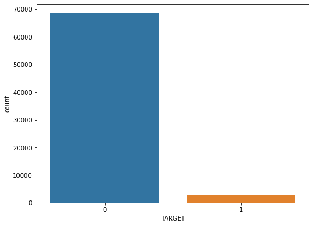

```python
# plot da variável target
plt.figure(figsize=(8,6))
sns.countplot(x = 'TARGET', data = dfTreino)
plt.show()
```

```python
# proporção da variável target
target_prop              = pd.DataFrame(dfTreino.TARGET.value_counts())
target_prop['Proporcao'] = round((100 * (target_prop.TARGET / target_prop.TARGET.sum())), 2)
target_prop
```

|  | TARGET | Proporcao |
| --- | --- | --- |
| 0 | 68398 | 96.05 |
| 1 | 2815 | 3.95 |

# 5.0 Feature Selection

É evidente que ainda temos muitas coluna, e se apresentassemos ao modelo o dataset dessa forma teríamos um problema de super dimensionalidade.

Portanto, irei aplicar algumas técnicas de seleção de variáveis.

```python
# seleção de variáveis.
# split dar features preditoras e targe.
x = dfTreino.iloc[:, :303]
y = dfTreino.iloc[:,  303]
```

## 5.1 Extra Trees Classifier

Utilizarei o algoritmo Extra Tree Classifier como indicador das melhores variáveis para o modelo.

O Extra Trees Classifier é um modelo de Machine Learning do conjunto de algoritmos que se baseiam fundamentalmente em árvores de decisão. Esse algortimo, assim como RandomForest, randomiza certas decisões e subconjuntos de dados para minimizar o over-learning dos dados e o overfitting.

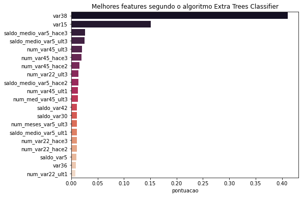

```python
# criação do modelo.
modelo_etc  = ExtraTreesClassifier(random_state = 0)
seletor_etc = modelo_etc.fit(x, y)

# dataframe com os resultados
resultados = pd.DataFrame({'pontuacao' : modelo_etc.feature_importances_,
                           'variavel'  : x.columns}).sort_values('pontuacao', ascending = False).reset_index(drop = True)

# plot
barPlot_h(resultados[0:20], 'variavel', 'pontuacao', 'Melhores features segundo o algoritmo Extra Trees Classifier')
```

## 5.2 Random Forest

As florestas aleatórias estão entre os métodos de aprendizado de máquina mais populares graças à sua precisão, robustez e facilidade de uso relativamente boas. Eles também fornecem dois métodos simples para a seleção de recursos: diminuição média de impureza e precisão de diminuição média.

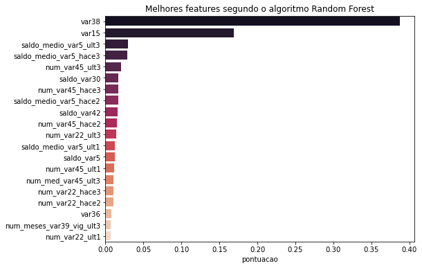

```python
# criação do modelo.
modelo_rf  = RandomForestClassifier(random_state = 0)
seletor_rf = modelo_rf.fit(x, y)

# dataframe com os resultados
resultados = pd.DataFrame({'pontuacao' : modelo_rf.feature_importances_,
                           'variavel'  : x.columns}).sort_values('pontuacao', ascending = False).reset_index(drop = True)

# plot
barPlot_h(resultados[0:20], 'variavel', 'pontuacao', 'Melhores features segundo o algoritmo Random Forest')
```

## 5.3 Variáveis Selecionadas

Criei novos dados aplicando a seleção feita, tanto para o ETC quanto para o RF. A quantidade de variáveis foi reduzida de 303 para 37.

```python
# capturando as melhores variáveis segundo cada algoritmo e gravando seus valores.
etc = SelectFromModel(seletor_etc, prefit = True)
rf  = SelectFromModel(seletor_rf,  prefit = True)

# valores das variáveis selecionadas
x_etc = etc.transform(x)
x_rf  = rf.transform(x)
print('Novo formato (ETC)', x_etc.shape)
print('Novo formato (RF)',  x_etc.shape)

# colocando apenas as variáveis selecionadas no dataset de teste.
# utilizarei apenas o que possuir maior acurácia. isso irei determinar através do treinamento
# com os dados de treino.
teste_etc = etc.transform(dfTeste)
teste_rf  = rf.transform(dfTeste)
```

```
Novo formato (ETC) (71213, 37)
Novo formato (RF) (71213, 37)
```

# 6.0 Construção dos Modelos

Vou fazer a construção dos modelos com os dados sem transformação, com normalização e com padronização.

## 6.1 Dados para Construção dos Modelos

### 6.1.1 Dados de Treino

##### variáveis preditoras

x_etc x_rf

##### variável Target

y

### 6.1.3 Algoritmos Utilizados

Vou utilizar vários algoritmos para o treinamento com o intuito de selecionar o melhor possível.

```python
# lista com todos os modelos que serão utilizados
modelos = []

modelos.append(('RF', RandomForestClassifier()))
modelos.append(('LR', LogisticRegression()))
modelos.append(('LDA', LinearDiscriminantAnalysis()))
modelos.append(('KNN', KNeighborsClassifier()))
modelos.append(('NB', GaussianNB()))
modelos.append(('SVM', SVC()))
modelos.append(('XGB', XGBClassifier()))
```

## 6.2 Treinamento dos Modelos

Irei realizar o treinamento com os dados das variáveis selecionadas através do ETC e do RF.

### 6.2.1 Treinamento com "x_etc"

#### 6.2.1.1 Dados sem Transformação

```
RF: 0.9516 (0.001536)
LR: 0.9604 (0.00091)
LDA: 0.9584 (0.000954)
KNN: 0.9586 (0.001153)
NB: 0.1393 (0.005174)
SVM: 0.9605 (0.000938)
XGB: 0.9601 (0.000709)

Média das acurácias:  84.13
Desvio padrão das acurácias: 0.287
```

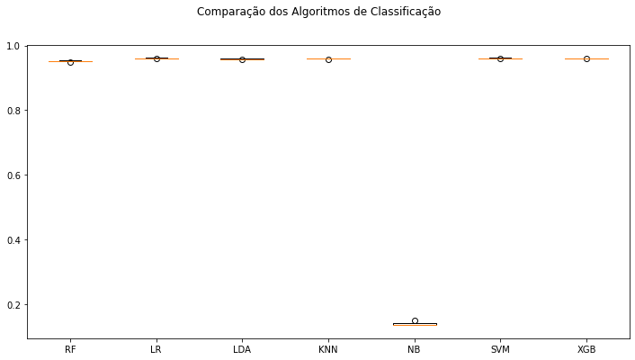

```python
treino_plot(modelos, x_etc, y)
```

#### 6.2.1.2 Dados Normalizados

```
RF: 0.9519 (0.001317)
LR: 0.9604 (0.000949)
LDA: 0.9584 (0.000954)
KNN: 0.9571 (0.001194)
NB: 0.2433 (0.097815)
SVM: 0.9605 (0.000938)
XGB: 0.9601 (0.000709)

Média das acurácias:  85.59
Desvio padrão das acurácias: 0.25
```

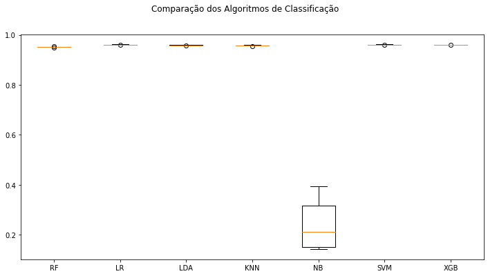

```python
treino_plot(modelos, min_max_scaler(x_etc), y)
```

#### 6.2.1.3 Dados Padronizados

```
RF: 0.9518 (0.00171)
LR: 0.9602 (0.000857)
LDA: 0.9584 (0.000954)
KNN: 0.9571 (0.001393)
NB: 0.2433 (0.097791)
SVM: 0.9605 (0.000938)
XGB: 0.9601 (0.000709)

Média das acurácias:  85.59
Desvio padrão das acurácias: 0.25
```

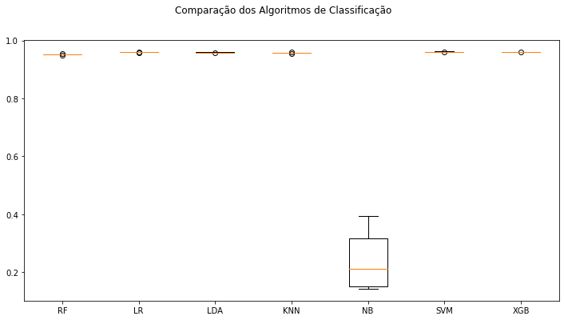

```python
treino_plot(modelos, standarization(x_etc), y)
```

### 6.2.2 Treinamento com "x_rf"

##### 6.2.2.1 Dados sem Transformação

```
RF: 0.9518 (0.001673)
LR: 0.9604 (0.000925)
LDA: 0.9586 (0.000984)
KNN: 0.9586 (0.001007)
NB: 0.1423 (0.006293)
SVM: 0.9605 (0.000938)
XGB: 0.9601 (0.000916)

Média das acurácias:  84.17
Desvio padrão das acurácias: 0.286
```

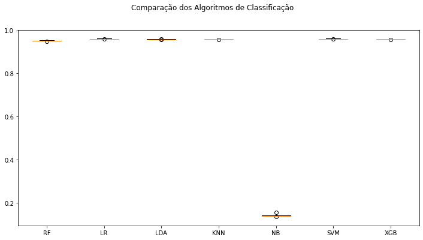

```python
treino_plot(modelos, x_rf, y)
```

#### 6.2.2.2 Dados Normalizados

```
RF: 0.952 (0.001718)
LR: 0.9604 (0.000958)
LDA: 0.9586 (0.000984)
KNN: 0.9571 (0.001178)
NB: 0.1572 (0.015612)
SVM: 0.9605 (0.000938)
XGB: 0.9601 (0.000916)

Média das acurácias:  84.37
Desvio padrão das acurácias: 0.28
```

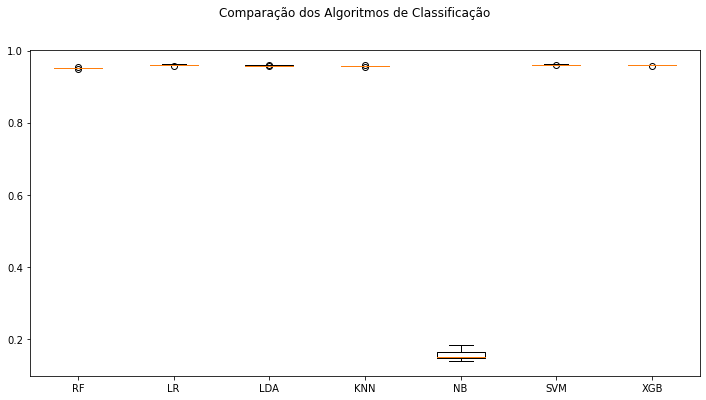

```python
treino_plot(modelos, min_max_scaler(x_rf), y)
```

#### 6.2.2.3 Dados Padronizados

```
RF: 0.9517 (0.001602)
LR: 0.9602 (0.000853)
LDA: 0.9586 (0.000984)
KNN: 0.9572 (0.001212)
NB: 0.1572 (0.015612)
SVM: 0.9605 (0.000938)
XGB: 0.9601 (0.000916)

Média das acurácias:  84.36
Desvio padrão das acurácias: 0.28
```

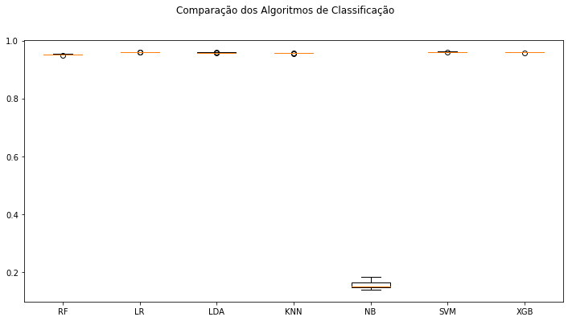

```python
treino_plot(modelos, standarization(x_rf), y)
```

## 6.3 Considerações Sobre os Modelos

- O modelo NB mostrou-se péssimo para fazer as previsões. Isso pode ter acontecido pela quantidade de variáveis apresentadas ao modelo.
- Os demais algoritmos apresentaram pouco ou nenhum ganho de acurácia, levando em consideração a combinação de transformação dos dados e os dois conjuntos de features selecionados.
- O dataset com a seleção de variáveis feita pelo ETC mostrou-se ligeiramente melhor que a feita pelo RF.

# 7.0 Otimizando o Modelo

Com a intenção de aumentar a acurácia do modelo, farei um ajuste dos parâmetros. Como nenhum algoritmo se mostrou muito melhor que os demais, irei utilziar o algoritmos XGBoost. Fiz essa escolha pelo fato desse algoritmos possuir um bom número de parâmetros para a otimização. Entretanto, isso não é garantia de melhores resultados frente aos outros.

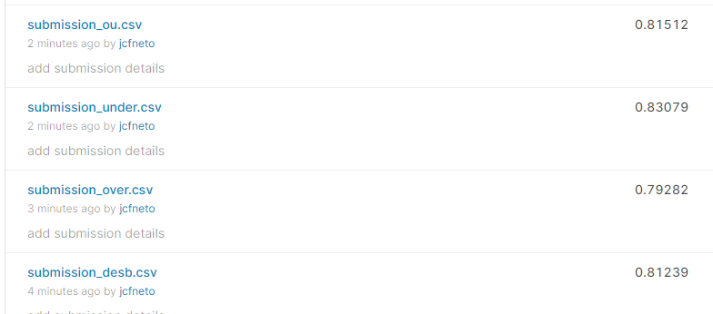

```python
# score area under the curve segundo o kaggle para as previsões feitas
Image(filename = '01.png')
```

## 7.1 Dados Sem Balanceamento

Como visto anteriormente, os dados estão desbalanceado. Vou otimizar o modelo com os dados dessa forma primeiramente e comparar com os resultados obtidos com os dados balanceado.

Dessa forma o modelo não mostrou-se muito bom para prever clientes insatisfeito.

```
Fitting 10 folds for each of 10 candidates, totalling 100 fits
```

```
[Parallel(n_jobs=-1)]: Using backend LokyBackend with 12 concurrent workers.
[Parallel(n_jobs=-1)]: Done  26 tasks      | elapsed:   21.4s
[Parallel(n_jobs=-1)]: Done 100 out of 100 | elapsed:   55.5s finished
```

```
Acurácia treino:  96.0541
Acurácia teste:  96.0307
```

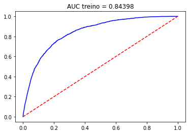

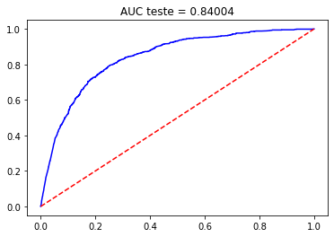

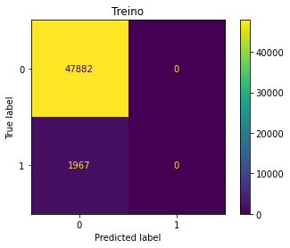

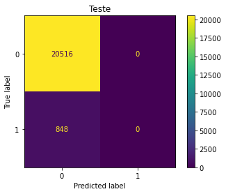

```
Relatório de classificação do teste:
               precision    recall  f1-score   support

           0       0.96      1.00      0.98     20516
           1       0.00      0.00      0.00       848

    accuracy                           0.96     21364
   macro avg       0.48      0.50      0.49     21364
weighted avg       0.92      0.96      0.94     21364
```

```python
# tuning
modelo_desb = otimizador(x_etc, y)
```

```python
# salvando o modelo
with open('modelo_desb.pkl', 'wb') as file_desb:
    pickle.dump(modelo_desb, file_desb)
```

### 7.1.1 Fazendo as Previsões

Irei fazer as previsões utilizando o modelo treinado e irei submeter ao kagle para calcular o score de AUC.

```python
# importando o modelo
with open('modelo.pkl', 'rb') as f_desb:
    modelo_desb = pickle.load(f_desb)

# fazendos as previsões e salvando no dataset
previsoes = pd.DataFrame({'ID'     : ID_teste,
                          'TARGET' : modelo_desb.predict_proba(teste_etc)[:, 1]})

# salvando as previsões
previsoes.to_csv('submission_desb.csv', index = False)
```

O modelo ganhou um score para AUC de 0.81239.

## 7.2 Balanceamento com Oversample

Fazendo o balanceamento utilizando Synthetic Minority Oversampling Technique (SMOTE).

```python
# balanceado os dados com oversample
oversample     = SMOTE()
x_over, y_over = oversample.fit_resample(x_etc, y)

# checando o balanceamento
y_over.value_counts()
```

```
1    68398
0    68398
Name: TARGET, dtype: int64
```

```
Fitting 10 folds for each of 10 candidates, totalling 100 fits
```

```
[Parallel(n_jobs=-1)]: Using backend LokyBackend with 12 concurrent workers.
[Parallel(n_jobs=-1)]: Done  26 tasks      | elapsed:   42.6s
[Parallel(n_jobs=-1)]: Done 100 out of 100 | elapsed:  2.1min finished
```

```
Acurácia treino:  98.2602
Acurácia teste:  97.6218
```

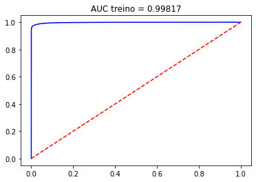

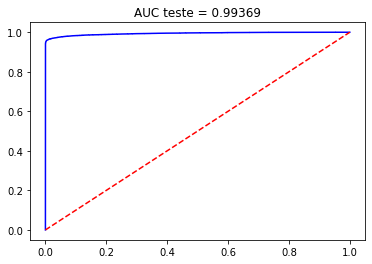

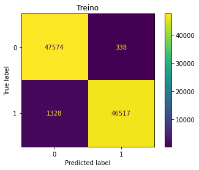

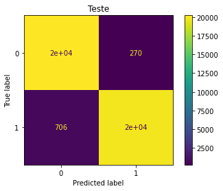

```
Relatório de classificação do teste:
               precision    recall  f1-score   support

           0       0.97      0.99      0.98     20486
           1       0.99      0.97      0.98     20553

    accuracy                           0.98     41039
   macro avg       0.98      0.98      0.98     41039
weighted avg       0.98      0.98      0.98     41039
```

```python
# tuning com os dados balanceados
modelo_over = otimizador(x_over, y_over)
```

```python
# salvando o modelo
with open('modelo_over.pkl', 'wb') as file_over:
    pickle.dump(modelo_over, file_over)
```

### 7.2.1 Fazendo as Previsões

Irei fazer as previsões utilizando o modelo treinado e irei submeter ao kagle para calcular o score de AUC.

```python
# importando o modelo
with open('modelo_over.pkl', 'rb') as f_over:
    modelo_over = pickle.load(f_over)

# fazendos as previsões e salvando no dataset
previsoes = pd.DataFrame({'ID'     : ID_teste,
                          'TARGET' : modelo_over.predict_proba(teste_etc)[:, 1]})

# salvando as previsões
previsoes.to_csv('submission_over.csv', index = False)
```

O modelo ganhou um score para AUC de 0.79282.

## 7.3 Balanceamento com Undersample

Fazendo o balanceamento utilizando RandomUnderSampler.

```python
# balanceado os dados com oversample
undersample      = RandomUnderSampler()
x_under, y_under = undersample.fit_resample(x_etc, y)

# checando o balanceamento
y_under.value_counts()
```

```
1    2815
0    2815
Name: TARGET, dtype: int64
```

```
Fitting 10 folds for each of 10 candidates, totalling 100 fits
```

```
[Parallel(n_jobs=-1)]: Using backend LokyBackend with 12 concurrent workers.
[Parallel(n_jobs=-1)]: Done  26 tasks      | elapsed:    1.5s
[Parallel(n_jobs=-1)]: Done 100 out of 100 | elapsed:    4.3s finished
```

```
Acurácia treino:  78.7871
Acurácia teste:  75.37
```

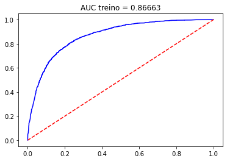

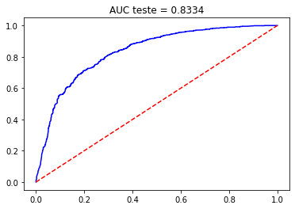

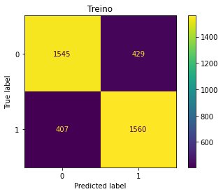

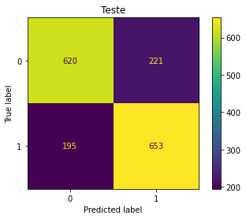

```
Relatório de classificação do teste:
               precision    recall  f1-score   support

           0       0.76      0.74      0.75       841
           1       0.75      0.77      0.76       848

    accuracy                           0.75      1689
   macro avg       0.75      0.75      0.75      1689
weighted avg       0.75      0.75      0.75      1689
```

```python
# tuning com os dados balanceados
modelo_under = otimizador(x_under, y_under)
```

```python
# salvando o modelo
with open('modelo_under.pkl', 'wb') as file_under:
    pickle.dump(modelo_under, file_under)
```

### 7.3.1 Fazendo as Previsões

Irei fazer as previsões utilizando o modelo treinado e irei submeter ao kagle para calcular o score de AUC.

```python
# importando o modelo
with open('modelo_under.pkl', 'rb') as f_under:
    modelo_under = pickle.load(f_under)

# fazendos as previsões e salvando no dataset
previsoes = pd.DataFrame({'ID'     : ID_teste,
                          'TARGET' : modelo_under.predict_proba(teste_etc)[:, 1]})

# salvando as previsões
previsoes.to_csv('submission_under.csv', index = False)
```

O modelo ganhou um score para AUC de 0.83079.

## 7.4 Combinando Oversample e Undersample

Combinando as técnicas de oversample e undersample.

```python
# balanceamento dos dados
passos = [('over', SMOTE(sampling_strategy = 0.1)),
          ('under', RandomUnderSampler(sampling_strategy = 0.5))]

# criando um pipeline
pipeline = Pipeline(steps = passos)

# resample
x_ou, y_ou = pipeline.fit_resample(x_etc, y)

# cheacando o resample
y_ou.value_counts()
```

```
0    13678
1     6839
Name: TARGET, dtype: int64
```

```
Fitting 10 folds for each of 10 candidates, totalling 100 fits
```

```
[Parallel(n_jobs=-1)]: Using backend LokyBackend with 12 concurrent workers.
[Parallel(n_jobs=-1)]: Done  26 tasks      | elapsed:    5.8s
[Parallel(n_jobs=-1)]: Done 100 out of 100 | elapsed:   17.0s finished
```

```
Acurácia treino:  94.1856
Acurácia teste:  87.6543
```

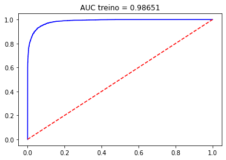

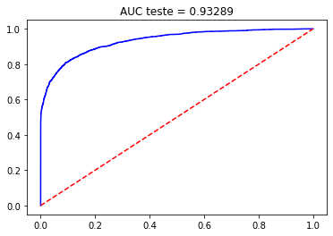

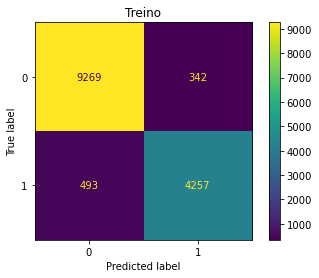

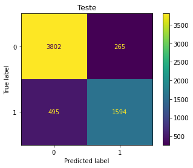

```
Relatório de classificação do teste:
               precision    recall  f1-score   support

           0       0.88      0.93      0.91      4067
           1       0.86      0.76      0.81      2089

    accuracy                           0.88      6156
   macro avg       0.87      0.85      0.86      6156
weighted avg       0.88      0.88      0.87      6156
```

```python
# tuning
modelo_ou = otimizador(x_ou, y_ou)
```

```python
# salvando o modelo
with open('modelo_ou.pkl', 'wb') as file_ou:
    pickle.dump(modelo_ou, file_ou)
```

### 7.4.1 Fazendo as Previsões

Irei fazer as previsões utilizando o modelo treinado e irei submeter ao kagle para calcular o score de AUC.

```python
# importando o modelo
with open('modelo_ou.pkl', 'rb') as f_ou:
    modelo_ou = pickle.load(f_ou)

# fazendos as previsões e salvando no dataset
previsoes = pd.DataFrame({'ID'     : ID_teste,
                          'TARGET' : modelo_ou.predict_proba(teste_etc)[:, 1]})

# salvando as previsões
previsoes.to_csv('submission_ou.csv', index = False)
```

O modelo ganhou um score para AUC de 0.81512.